# Assignment 2 - DS4Biz Y63

## TextScraping_Classification : Quotes

### Team Detail

**Team Name**: TomandJerry

### *Student 1*

**Student ID**: 61070306  
**Student Full Name**: นางสาว ปรียานุช สุภาสืบ

### *Student 2*

**Student ID**: 61070365  
**Student Full Name**: นางสาว อารีญา สมิงแก้ว

```python
import urllib.request
import requests
from bs4 import BeautifulSoup as soup
import pandas as pd
import numpy as np
from sklearn.feature_extraction.text import TfidfTransformer
from sklearn.preprocessing import MultiLabelBinarizer
from sklearn.feature_extraction.text import TfidfVectorizer
import xgboost
from sklearn.neighbors import KNeighborsClassifier
from sklearn.model_selection import KFold
from sklearn.metrics import accuracy_score,classification_report
from sklearn.model_selection import train_test_split
from sklearn.model_selection import GridSearchCV
from sklearn.model_selection import cross_val_score
from sklearn.model_selection import StratifiedKFold
from sklearn.metrics import accuracy_score, precision_score, recall_score, f1_score
from xgboost import XGBClassifier
from sklearn.ensemble import RandomForestClassifier
from sklearn.feature_extraction.text import CountVectorizer
from sklearn.feature_extraction import text
import nltk
```

# Data Collection

## Web Scraping

ทำการดึงข้อมูลภายในหน้าเว็บ https://quotes.toscrape.com/ เพื่อมาใช้ในการวิเคราะห์ข้อมูลหาโมเดลในการติดแท็กของข้อมูล quotes ที่เข้ามาใหม่ได้

```python
#สร้าง list total_url เพื่อเก็บข้อมูลของ url หน้า web page ทั้งหมดที่ต้องการดึงข้อมูล
total_url = []
i = 1
while True: #วนลูปหา url ของหน้า web page ทั้งหมด ใช้วิธีการร้องขอด้วย requests
    url = "https://quotes.toscrape.com/page/{}/".format(i)
    r = requests.get(url)
    soupp = soup(r.content,'html.parser')
    test = soupp.findAll('div',{'class':'col-md-8'})
    #ถ้าหากหน้า url มีเนื้อหาว่า No quotes found! ให้ break
    if test[1].text == '\n\nNo quotes found!\n\n    \n\n\n← Previous\n\n\n\n':
        break
    else:
        total_url.append(url)
        i += 1
```

```python
total_url
```

```
['https://quotes.toscrape.com/page/1/',
 'https://quotes.toscrape.com/page/2/',
 'https://quotes.toscrape.com/page/3/',
 'https://quotes.toscrape.com/page/4/',
 'https://quotes.toscrape.com/page/5/',
 'https://quotes.toscrape.com/page/6/',
 'https://quotes.toscrape.com/page/7/',
 'https://quotes.toscrape.com/page/8/',
 'https://quotes.toscrape.com/page/9/',
 'https://quotes.toscrape.com/page/10/']
```

จากผลลัพธ์ด้านบนจะพบว่ามีหน้า web page ที่ดึง url มาได้ทั้งหมดมี 10 url

ข้อมูลภายในหน้าเว็บนี้จะมี quote อยู่ในแต่ละกล่องข้อความ

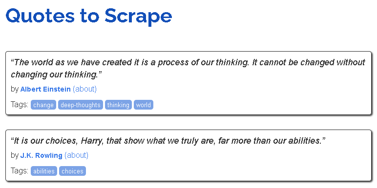

โดยจะทำการสร้าง function เพื่อดึงข้อมูลที่ต้องการภายในหน้า web page ของแต่ละ url

#### ฟังก์ชั่น scrape_quote(data) ดึงข้อมูลส่วนของเนื้อหา quote

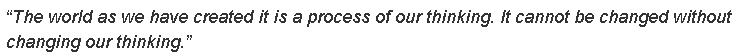

```python
def scrape_quote(data):
    quote = []
    desc = data.findAll('span',{'class':'text'}) #หา tag html ที่มี class = text ที่มี เนื้อหา quote อยู่
    # วนลูปเพื่อเก็บ quote ไว้ใน list quote
    for a in range(0,len(desc)):
        quote.append(desc[a].text.replace('\'','').replace('“','').replace('”',''))

    return quote
```

#### ฟังก์ชั่น scrape_tags(data) ดึงข้อมูลส่วนของ tags ที่ถูกติดให้ของแต่ละ quotes

```python
def scrape_tags(data):
    tags = []
    test3 = data.findAll('meta',content=True)  #หา tag html meta ที่มีส่วนของ tags อยู่
    # วนลูปเพื่อเก็บ tags ไว้ใน list tags
    for b in range(0,len(test3)):
         tags.append(test3[b]['content'])

    return tags
```

#### ฟังก์ชั่น scrape_name_author(data) ดึงข้อมูลในส่วนของชื่อผู้เขียน

```python
def scrape_name_author(data):
    name_author = []
    test2 = data.findAll('small',{'class':'author'}) #หา tag html small ที่มี class = author มีเนื้อหาส่วนของ ชื่อผู้เขียน อยู่
    # วนลูปเพื่อเก็บ ชื่อผู้เขียน ไว้ใน list name_author
    for j in range(0,len(test2)):
        name_author.append(test2[j].text)

    return name_author
```

#### ฟังก์ชั่น scrape_hbd_author(data2) ดึงข้อมูลในส่วนของวันเกิดของผู้เขียน

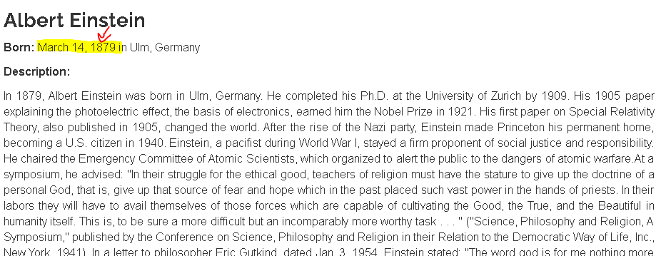

```python
def scrape_hbd_author(data2):
    hbd_author = []
    #หา tag html span ที่มี class = author-born-date มีเนื้อหาส่วนของ วันเกิดผู้เขียน อยู่
    hbd_au = data2.findAll('span',{'class': 'author-born-date'})[0].text
    # วนลูปเพื่อเก็บ วันเกิดผู้เขียนไว้ใน list hbd_author
    hbd_author.append(hbd_au)

    return hbd_author
```

#### ฟังก์ชั่น scrape_hbdlo_author(data2) ดึงข้อมูลในส่วนของสถานที่เกิดของผู้เขียน

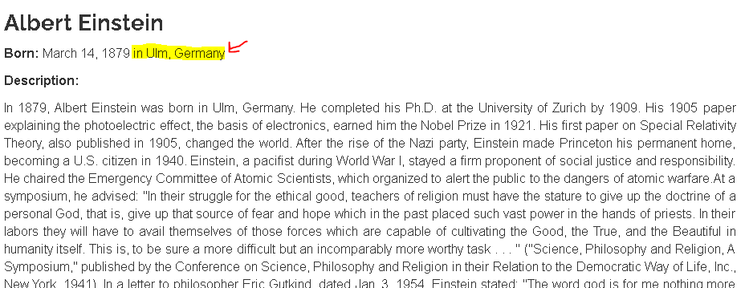

```python
def scrape_hbdlo_author(data2):
    hbdlo_author = []

    #หา tag html span ที่มี class = author-born-location มีเนื้อหาส่วนของ สถานที่เกิดผู้เขียน อยู่
    hbdlo_au = data2.findAll('span',{'class': 'author-born-location'})[0].text
    hbdlo_author.append(hbdlo_au[3:])
    # วนลูปเพื่อเก็บ สถานที่เกิดผู้เขียนไว้ใน list hbdlo_author
    return hbdlo_author
```

#### ฟังก์ชั่น scrape_des_author(data2) ดึงข้อมูลในส่วนของประวัติของผู้เขียน

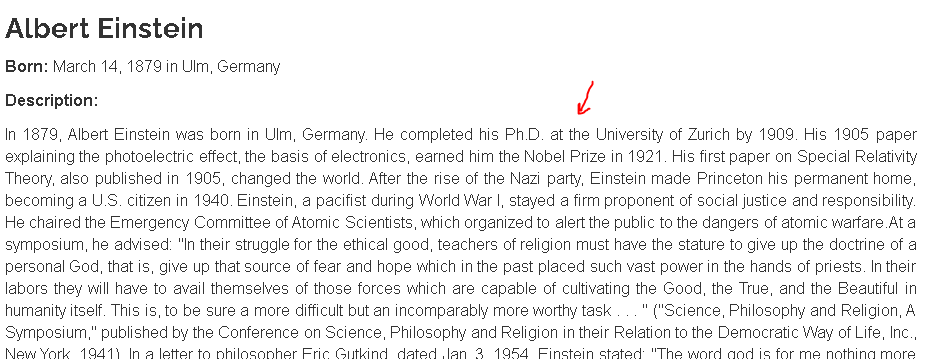

```python
def scrape_des_author(data2):
    des_author = []
    #หา tag html div ที่มี class = author-description มีเนื้อหาส่วนของ ประวัติผู้เขียน อยู่
    des_au = data2.findAll('div',{'class': 'author-description'})[0].text
    # วนลูปเพื่อเก็บ ประวัติผู้เขียนไว้ใน list des_author
    des_author.append(des_au.replace('\n        ','').replace('    \n    ',''))
    return des_author
```

#### ฟังก์ชั่น scrape_link_about(data) ดึงข้อมูล url link about ของแต่ละ quote

ซึ่งภายใน link about จะมีหน้า web ดังนี้

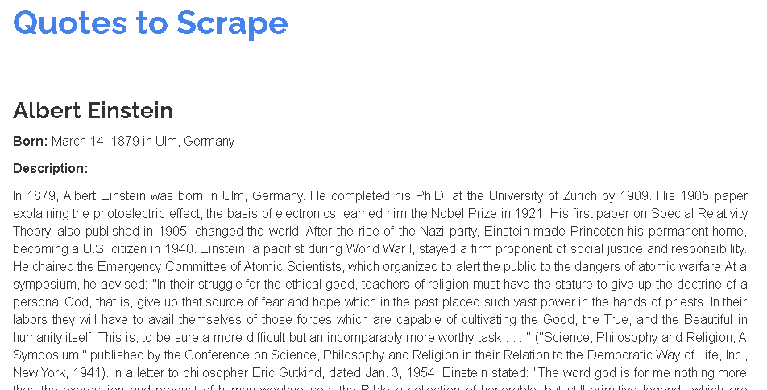

โดยจะทำการเรียกใช้ฟังก์ชั่น scrape_hbd_author(data2), scrape_hbdlo_author(data2), scrape_des_author(data2) เพื่อดึงข้อมูลภายในหน้า web page link about นี้

```python
def scrape_link_about(data):
    check_link_about = []
    check = []

    #ให้ test4 ค้นหา tag html ที่เป็น a
    test4 = data.findAll('a')

    #วนลูปเพื่อหา url link about ของแต่ละ quote โดยข้อมูลที่ได้จะได้เพียง "/author/Albert-Einstein" แล้วเก็บข้อมูลไว้ใน list check_link_about
    for k in range(0,len(test4)):
        if test4[k].text == '(about)':
            check_link_about.append(test4[k]['href'])
        else:
            pass
    #วนลูปเพื่อสร้าง url ที่สมบูรณ์ โดย m คือข้อมูลภายใน list check_link_about เอามาต่อเข้ากับ 'https://quotes.toscrape.com' เพื่อได้เป็น url link about
    #ของแต่ละ quote ในการนำไปดึงข้อมูลภายใน url นั้นได้ แล้วเก็บไว้ใน list check
    for m in check_link_about:
        total_link_au = 'https://quotes.toscrape.com'+ m
        check.append(total_link_au)
     # วนลูปเพื่อ Parsing html ของแต่ละ url ใน list check
    for n in check:
        url = n + '/'
        response = urllib.request.urlopen(url)
        html = response.read().decode()
        data2 = soup(html,'html.parser')

        #เรียกใช้ฟังก์ชั่น scrape_hbd_author(data2) ดึงข้อมูลวันเกิดของผู้เขียน
        for i in scrape_hbd_author(data2):
            all_hbd_author.append(i)

        #เรียกใช้ฟังก์ชั่น scrape_hbdlo_author(data2) ดึงข้อมูลสถานที่เกิดของผู้เขียน
        for j in scrape_hbdlo_author(data2):
            all_hbdlo_author.append(j)

        #เรียกใช้ฟังก์ชั่น scrape_des_author(data2) ดึงข้อมูลประวัติของผู้เขียน
        for f in scrape_des_author(data2):
            all_des_author.append(f)
```

พอสร้างังก์ชั่นดึงข้อมูลจากหน้า web page link about ได้เสร็จแล้วจะทำการดึงข้อมูลจากหน้าเว็บหลักของแต่ละ quote

```python
all_quote = [] #เก็บ quote ทั้งหมด
all_tags = [] #เก็บ tags ทั้งหมด
all_name_author = [] #เก็บชื่อผู้เขียนทั้งหมด
all_hbd_author = [] #เก็บวันเกิดผู้เขียนทั้งหมด
all_hbdlo_author = [] #เก็บสถานที่เกิดผู้เขียนทั้งหมด
all_des_author = [] #เก็บประวัติผู้เขียนทั้งหมด

#วนลูป url ของหน้าเว็บหลักทั้ง 10 url
for i in total_url:
    #parsing html ของแต่ละ url
    response = urllib.request.urlopen(i)
    html = response.read().decode()
    response.close()
    data = soup(html,'html.parser')
    # วนลูปในฟังก์ชั่น scrape_quote(data) เพื่อเก็บข้อมูลเนื้อหา quote
    for i in scrape_quote(data):
        all_quote.append(i)
    # วนลูปในฟังก์ชั่น scrape_tags(data) เพื่อเก็บข้อมูล tags
    for b in scrape_tags(data):
        all_tags.append(b)
    # วนลูปในฟังก์ชั่น scrape_name_author(data) เพื่อเก็บข้อมูล ชื่อผู้เขียน
    for j in scrape_name_author(data):
        all_name_author.append(j)
    # เรียกใช้ฟังก์ชั่น scrape_link_about(data) เพื่อดึงข้อมูลภายในหน้า web page ของ link about
    # ซึ่งจะได้ข้อมูล วันเกิดผู้เขียน สถานที่เกิดผู้เขียน และ ประวัติผู้เขียน
    scrape_link_about(data)
```

```python
#ทำการแปลงจาก list to dataframe
all_quote = pd.Series(all_quote)
all_tags = pd.Series(all_tags)
all_name_author = pd.Series(all_name_author)
all_hbd_author = pd.Series(all_hbd_author)
all_hbdlo_author = pd.Series(all_hbdlo_author)
all_des_author = pd.Series(all_des_author)
# รวม dataframe ทุกอันเข้าด้วยกัน
df = pd.concat([all_quote, all_tags,all_name_author,all_hbd_author,all_hbdlo_author,all_des_author], axis=1)

#เปลี่ยนชื่อของแต่ละ columns ภายใน dataframe
df = df.rename(columns={0 : 'quote', 1 : 'tags', 2 : 'name_author', 3 : 'hbd_author', 4 : 'hbdlo_author', 5 : 'des_author'})

# check ว่าแต่ละคอลัมน์มีค่า null ไหม
df.isnull().sum()
```

```
quote           0
tags            0
name_author     0
hbd_author      0
hbdlo_author    0
des_author      0
dtype: int64
```

จากผลลัพธ์แต่ละ columns ไม่มีค่า null

## Save To Folder

save ข้อมูลที่ได้ลง folder ต่างๆดังนี้

```python
#save ข้อมูล dataframe ทั้งหมดที่ได้ลง folder datastore แบบ csv
df.to_csv(r'datastore\allll.csv', index = False)
# save ข้อมูล dataframe ทั้งหมดที่ไม่มี tags ลง folder datastore แบบ txt
np.savetxt(r'datastore\allll.txt', df.values , fmt='%s',encoding='utf-8')

#save ข้อมูล dataframe ทั้งหมดที่ไม่มี tags ลง folder datastore แบบ csv
df.drop('tags',axis='columns', inplace=False).to_csv(r'datastore\feature.csv',index=False)
# save ข้อมูล dataframe ทั้งหมดที่ไม่มี tags ลง folder datastore แบบ txt
np.savetxt(r'datastore\feature.txt', df.drop('tags',axis='columns', inplace=False).values , fmt='%s',encoding='utf-8')

#save ข้อมูล dataframe ที่มีแต่ quote ลง folder datastore แบบ csv
df['quote'].to_csv(r'datastore\quote.csv',index=False)
# save ข้อมูล dataframe ที่มีแต่ quote ลง folder datastore แบบ txt
np.savetxt(r'datastore\quote.txt', df['quote'].values , fmt='%s',encoding='utf-8')

#save ข้อมูล dataframe ที่มีแต่ tags ลง folder target แบบ csv
df['tags'].to_csv(r'target\tags.csv',index=False)
# save ข้อมูล dataframe ที่มีแต่ tags ลง folder target แบบ txt
np.savetxt(r'target\tags.txt', df['tags'].values , fmt='%s')
```

## Import Data

ทำการนำเข้าข้อมูลที่เก็บไว้ใน folder ต่างๆดังนี้

```python
#ทำการนำเข้าข้อมูลไฟล์ txt ของข้อมูล quote ซึ่งเป็น feature
listt = []
fin = open("datastore/quote.txt","r",encoding="utf8")
for l in fin: # readline txt ไฟล์ quote
    l = l.strip() # เอาแต่ส่วนเนื้อหา
    listt.append(l) # เพิ่มข้อมูลเข้า list listt
feature = pd.Series(listt) # แปลงจาก list to dataframe
fin.close()
```

```python
#ทำการนำเข้าข้อมูลไฟล์ txt ของข้อมูล tags ซึ่งเป็น target
list1 = []
fin = open("target/tags.txt","r")
for l in fin.readlines(): # readline txt ไฟล์ target
    l = l.strip() # เอาแต่ส่วนเนื้อหา
    list1.append(l) # เพิ่มข้อมูลเข้า list listt
all_tags = pd.Series(list1) # แปลงจาก list to dataframe
fin.close()
```

## Change Label

ต่อมาจะทำการแปลงข้อมูลจาก label tags จาก categorical ดัง code ด้านล่างไปเป็น numerical สำหรับเตรียมไปใช้ในการทำนายโมเดล

เนื่องจากข้อมูล target เป็น multilabel คือ มีหลาย target จึงใช้การแปลงด้วยคำสั่ง mlb = MultiLabelBinarizer() ดังกระบวนการด้านล่างนี้

```python
all_tags
```

```
0                   change,deep-thoughts,thinking,world
1                                     abilities,choices
2              inspirational,life,live,miracle,miracles
3                         aliteracy,books,classic,humor
4                             be-yourself,inspirational
                            ...
95                                  better-life-empathy
96    books,children,difficult,grown-ups,write,write...
97                                                truth
98                                        inspirational
99                                           books,mind
Length: 100, dtype: object
```

```python
# จัดการค่า null ถ้าหากพบค่า null ให้ใส่คำว่า no tags แทน
all_tags.fillna('no tags', inplace=True)
```

```python
#แต่จะสังเกตได้ว่า tags มีค่า '' ซึ่งเป็นค่า null อยู่จาก code ด้านล่าง
all_tags[27]
```

```
''
```

```python
# สร้าง list_tags เป็น list ที่เก็บช้อมูลของ tags ของแต่ละ quote
list_tags = []
summ = 0
for i in all_tags: # วนลูปของข้อมูลภายใน dataframe all_tags

    if type(i) == str: #ค่าที่เป็น str ให้ทำการ split ด้วย , แล้วเก็บเข้าสู่ list_tags
        dd = i.split(',')
        list_tags.append(dd)

    else:
        list_tags.append([i]) # จัดการค่าที่มี type ไม่เป็น string โดยการใส่ [] แล้วเก็บเข้าสู่ list_tags

    summ +=1
```

```python
list_tags
```

```
[['change', 'deep-thoughts', 'thinking', 'world'],
 ['abilities', 'choices'],
 ['inspirational', 'life', 'live', 'miracle', 'miracles'],
 ['aliteracy', 'books', 'classic', 'humor'],
 ['be-yourself', 'inspirational'],
 ['adulthood', 'success', 'value'],
 ['life', 'love'],
 ['edison', 'failure', 'inspirational', 'paraphrased'],
 ['misattributed-eleanor-roosevelt'],
 ['humor', 'obvious', 'simile'],
 ['friends', 'heartbreak', 'inspirational', 'life', 'love', 'sisters'],
 ['courage', 'friends'],
 ['simplicity', 'understand'],
 ['love'],
 ['fantasy'],
 ['life', 'navigation'],
 ['activism',
  'apathy',
  'hate',
  'indifference',
  'inspirational',
  'love',
  'opposite',
  'philosophy'],
 ['friendship',
  'lack-of-friendship',
  'lack-of-love',
  'love',
  'marriage',
  'unhappy-marriage'],
 ['books', 'contentment', 'friends', 'friendship', 'life'],
 ['fate', 'life', 'misattributed-john-lennon', 'planning', 'plans'],
 ['love', 'poetry'],
 ['happiness'],
 ['attributed-no-source'],
 ['humor', 'religion'],
 ['humor'],
 ['comedy', 'life', 'yourself'],
 ['children', 'fairy-tales'],
 [''],
```

[output cut: 70 more lines]

```
 ['death', 'life'],
 ['adventure', 'love'],
 ['courage'],
 ['life'],
 ['better-life-empathy'],
 ['books',
  'children',
  'difficult',
  'grown-ups',
  'write',
  'writers',
  'writing'],
 ['truth'],
 ['inspirational'],
 ['books', 'mind']]
```

```python
#ทำการแปลงข้อมูลจาก ตัวอักษรให้เป็นตัวเลข ด้วย MultiLabelBinarizer()
mlb = MultiLabelBinarizer()
y = mlb.fit_transform(list_tags)
y #จะเห็นได้ว่าค่า y ที่ได้ออกมาเป็นตัวเลขแล้ว
```

```
array([[0, 0, 0, ..., 0, 0, 0],
       [0, 1, 0, ..., 0, 0, 0],
       [0, 0, 0, ..., 0, 0, 0],
       ...,
       [0, 0, 0, ..., 0, 0, 0],
       [0, 0, 0, ..., 0, 0, 0],
       [0, 0, 0, ..., 0, 0, 0]])
```

```python
#แปลง label ที่ได้เป็นตัวเลขจาก list to dataframe
label = pd.DataFrame(mlb.fit_transform(list_tags), columns= mlb.classes_)
label
```

|  |  | abilities | activism | adulthood | adventure | age | alcohol | aliteracy | apathy | attributed | ... | unhappy-marriage | value | wander | wisdom | women | world | write | writers | writing | yourself |
| --- | --- | --- | --- | --- | --- | --- | --- | --- | --- | --- | --- | --- | --- | --- | --- | --- | --- | --- | --- | --- | --- |
| 0 | 0 | 0 | 0 | 0 | 0 | 0 | 0 | 0 | 0 | 0 | ... | 0 | 0 | 0 | 0 | 0 | 1 | 0 | 0 | 0 | 0 |
| 1 | 0 | 1 | 0 | 0 | 0 | 0 | 0 | 0 | 0 | 0 | ... | 0 | 0 | 0 | 0 | 0 | 0 | 0 | 0 | 0 | 0 |
| 2 | 0 | 0 | 0 | 0 | 0 | 0 | 0 | 0 | 0 | 0 | ... | 0 | 0 | 0 | 0 | 0 | 0 | 0 | 0 | 0 | 0 |
| 3 | 0 | 0 | 0 | 0 | 0 | 0 | 0 | 1 | 0 | 0 | ... | 0 | 0 | 0 | 0 | 0 | 0 | 0 | 0 | 0 | 0 |
| 4 | 0 | 0 | 0 | 0 | 0 | 0 | 0 | 0 | 0 | 0 | ... | 0 | 0 | 0 | 0 | 0 | 0 | 0 | 0 | 0 | 0 |
| ... | ... | ... | ... | ... | ... | ... | ... | ... | ... | ... | ... | ... | ... | ... | ... | ... | ... | ... | ... | ... | ... |
| 95 | 0 | 0 | 0 | 0 | 0 | 0 | 0 | 0 | 0 | 0 | ... | 0 | 0 | 0 | 0 | 0 | 0 | 0 | 0 | 0 | 0 |
| 96 | 0 | 0 | 0 | 0 | 0 | 0 | 0 | 0 | 0 | 0 | ... | 0 | 0 | 0 | 0 | 0 | 0 | 1 | 1 | 1 | 0 |
| 97 | 0 | 0 | 0 | 0 | 0 | 0 | 0 | 0 | 0 | 0 | ... | 0 | 0 | 0 | 0 | 0 | 0 | 0 | 0 | 0 | 0 |
| 98 | 0 | 0 | 0 | 0 | 0 | 0 | 0 | 0 | 0 | 0 | ... | 0 | 0 | 0 | 0 | 0 | 0 | 0 | 0 | 0 | 0 |
| 99 | 0 | 0 | 0 | 0 | 0 | 0 | 0 | 0 | 0 | 0 | ... | 0 | 0 | 0 | 0 | 0 | 0 | 0 | 0 | 0 | 0 |

100 rows × 138 columns

```python
# ทำาการ sum ข้อมูล tags ที่ พบมากที่สุดแล้ว sort ติดอันดับ 15 ตัวแรก จากมากไปน้อย
sum_label = label.sum(axis=0)
sum_label2 = sum_label.sort_values(ascending=False)
sum_label2.nlargest(16) # ตั้ง 16 เนื่องจาก ใน 15 ตัวแรกมีข้อมูลที่เป็น no tags มาด้วย
```

```
love                    14
life                    13
inspirational           13
humor                   12
books                   11
reading                  7
friendship               5
truth                    4
friends                  4
writing                  3
                         3
death                    3
attributed-no-source     3
simile                   3
hope                     2
religion                 2
dtype: int64
```

```python
# สร้าง dataframe of top 15 ที่ได้มาจากการ sort จากผลลัพธ์ด้านบน
label_top15 = label[['love','life','inspirational','humor','books','reading'
        ,'friendship','truth','friends','writing','simile','death'
        ,'attributed-no-source','religion','hope']]
label_top15
```

|  | love | life | inspirational | humor | books | reading | friendship | truth | friends | writing | simile | death | attributed-no-source | religion | hope |
| --- | --- | --- | --- | --- | --- | --- | --- | --- | --- | --- | --- | --- | --- | --- | --- |
| 0 | 0 | 0 | 0 | 0 | 0 | 0 | 0 | 0 | 0 | 0 | 0 | 0 | 0 | 0 | 0 |
| 1 | 0 | 0 | 0 | 0 | 0 | 0 | 0 | 0 | 0 | 0 | 0 | 0 | 0 | 0 | 0 |
| 2 | 0 | 1 | 1 | 0 | 0 | 0 | 0 | 0 | 0 | 0 | 0 | 0 | 0 | 0 | 0 |
| 3 | 0 | 0 | 0 | 1 | 1 | 0 | 0 | 0 | 0 | 0 | 0 | 0 | 0 | 0 | 0 |
| 4 | 0 | 0 | 1 | 0 | 0 | 0 | 0 | 0 | 0 | 0 | 0 | 0 | 0 | 0 | 0 |
| ... | ... | ... | ... | ... | ... | ... | ... | ... | ... | ... | ... | ... | ... | ... | ... |
| 95 | 0 | 0 | 0 | 0 | 0 | 0 | 0 | 0 | 0 | 0 | 0 | 0 | 0 | 0 | 0 |
| 96 | 0 | 0 | 0 | 0 | 1 | 0 | 0 | 0 | 0 | 1 | 0 | 0 | 0 | 0 | 0 |
| 97 | 0 | 0 | 0 | 0 | 0 | 0 | 0 | 1 | 0 | 0 | 0 | 0 | 0 | 0 | 0 |
| 98 | 0 | 0 | 1 | 0 | 0 | 0 | 0 | 0 | 0 | 0 | 0 | 0 | 0 | 0 | 0 |
| 99 | 0 | 0 | 0 | 0 | 1 | 0 | 0 | 0 | 0 | 0 | 0 | 0 | 0 | 0 | 0 |

100 rows × 15 columns

```python
# สร้าง dataframe โดยการนำ dataframe ของ feature และ label_top15 มารวมกัน
df = pd.concat([feature,label_top15], axis=1)
df.head(5) # แสดงข้อมูล 5 ตัวแรก
```

|  | 0 | love | life | inspirational | humor | books | reading | friendship | truth | friends | writing | simile | death | attributed-no-source | religion | hope |
| --- | --- | --- | --- | --- | --- | --- | --- | --- | --- | --- | --- | --- | --- | --- | --- | --- |
| 0 | The world as we have created it is a process o... | 0 | 0 | 0 | 0 | 0 | 0 | 0 | 0 | 0 | 0 | 0 | 0 | 0 | 0 | 0 |
| 1 | It is our choices, Harry, that show what we tr... | 0 | 0 | 0 | 0 | 0 | 0 | 0 | 0 | 0 | 0 | 0 | 0 | 0 | 0 | 0 |
| 2 | There are only two ways to live your life. One... | 0 | 1 | 1 | 0 | 0 | 0 | 0 | 0 | 0 | 0 | 0 | 0 | 0 | 0 | 0 |
| 3 | The person, be it gentleman or lady, who has n... | 0 | 0 | 0 | 1 | 1 | 0 | 0 | 0 | 0 | 0 | 0 | 0 | 0 | 0 | 0 |
| 4 | Imperfection is beauty, madness is genius and ... | 0 | 0 | 1 | 0 | 0 | 0 | 0 | 0 | 0 | 0 | 0 | 0 | 0 | 0 | 0 |

## Text Pre- Process

ทำ Text Pre- Process ของข้อมูล feature ซึ่งเป็น unstructure data(text) ให้อยู่ในรูปของ structure data(dataframe ตารางที่เข้าใจได้ง่ายนำไปใช้วิเคราะห์ข้อมูลต่อไปได้) ด้วยกระบวนการดังนี้

1. tokenisation เป็นกระบวนการตัดคำจากประโยคภาษาอังกฤษจาก white space ให้จากประโยค กลายเป็น คำ
2. case conversation เป็นกระบวนการแปลงจากตัวอักษรพิมพ์ใหญ่ให้เป็นพิมพ์เล็ก
3. filter stop words กระบวนการกำจัดคำที่ไม่มีความหมาย ยกตัวอย่างเช่น a and the
4. Lemmatise และ POS tag กระบวนการลดรูปคำ กลายเป็น common form ของคำ โดยจะใช้ POS tag เข้ามาใช้ POS tag จะเป็นการหาว่าคำมีหน้าที่อย่างไรในประโยคภาษาอังกฤษ เป็นกริยา หรือ คำนามของประโยคให้ลดรูปคำได้เก่งขึ้น
5. TF-IDF weight การถ่วงน้ำหนักของคำเพื่อหาว่าคำนั้นมีพลังในการแยกแยะเอกสารมากน้อยขนาดไหนจึงใช้ weight เข้ามาช่วยถ่วงน้ำหนักคำว่ามีความสำคัญมากน้อยขนาดไหน

```python
#Tokenizer and WordNet Lemmatizer with POS
#สร้าง function lemma_tokenizer_w_pos_tag(text) ในการทำ text pre process
def lemma_tokenizer_w_pos_tag(text):

    # สร้างฟังก์ชั่นในการแปลง POS tag ต่างๆ สำหรับใช้กับ Lemmatizer
    def convert_tags(tag):
        if tag == 'vbd' or tag == 'vbg' or tag == 'vbz': #ถ้า tag = vbd,vbg,vbz ให้ return เป็น v(verb)
            return 'v'
        else:  #ถ้าไม่ใช่ให้ return เป็น n(noun)
            return 'n'

    #ทำการตัดคำด้วย standard_tokenizer
    standard_tokenizer = CountVectorizer().build_tokenizer()
    #print(standard_tokenizer)
    tokens = standard_tokenizer(text)
    #print(tokens)

    #ทำการตัดคำด้วย pos tag
    tokens_with_pos_tag = nltk.pos_tag(tokens)
    #print(tokens_with_pos_tag)

    # ใช้ NLTK ในการ lemmatisation(ลดรูปคำแต่ละคำ)
    lemmatizer = nltk.WordNetLemmatizer()
    lemma_tokens = []

    for token in tokens_with_pos_tag: #วนลูปของแต่ละ token
    #print(token)
    #print(token[1].lower())
        new_tag = convert_tags(token[1].lower())  #เรียกใช้ฟังก์ชั่น convert_tags ในการแปลง POS tag และทำให้เป็นตัวอักษรพิมพ์เล็กทั้งหมด
    #print(new_tag)
    #dd = lemmatizer.lemmatize(token[0])
    #print(dd)
        lemma_tokens.append(lemmatizer.lemmatize(token[0], new_tag)) #ทำการลดรูปคำแล้วเก็บไว้ใน lemma_tokens

    #print(lemma_tokens)
    return lemma_tokens
```

```python
# ใช้ CountVectorizer ในการทำ Bag of Word ของ feature
# โดยการให้ stop_words = english คือเอาคำที่อยู่ใน list english ออก
# min_df = 0 คือ ถ้าคำนั้นปรากฎในเอกสารน้อยกว่า 0 ครั้งจะถูก remove
# tokenizer = lemma_tokenizer_w_pos_tag คือใช้การตัดคำด้วยการเรียกใช้ ฟังก์ชั่น lemma_tokenizer_w_pos_tag
vectorizer = CountVectorizer(stop_words="english",min_df = 0,tokenizer=lemma_tokenizer_w_pos_tag)
X = vectorizer.fit_transform(feature)
print(X.shape)
```

```
(100, 454)
```

```python
# ทำการ normalize ให้ค่าของแต่ละคำอยู่ระหว่าง  0 - 1
tfidf_transformer = TfidfTransformer()
X_Tfidf = tfidf_transformer.fit_transform(X)
print('Train size: ',X_Tfidf.shape)
print(X_Tfidf.todense())
```

```
Train size:  (100, 454)
[[0.         0.         0.         ... 0.         0.         0.        ]
 [0.         0.         0.47553121 ... 0.         0.         0.        ]
 [0.         0.         0.         ... 0.         0.         0.        ]
 ...
 [0.         0.         0.         ... 0.         0.         0.        ]
 [0.         0.         0.         ... 0.         0.         0.        ]
 [0.         0.         0.         ... 0.         0.         0.        ]]
```

```python
# คำสั่งแสดงจำนวนคำที่ถูกตัดมาแล้วทั้งหมด
terms = vectorizer.get_feature_names()
print("Vocabulary has %d distinct terms" % len(terms))
```

```
Vocabulary has 454 distinct terms
```

```python
# คำสั่งแสดง คำที่ถูกตัดมาแล้ว 100 ตัวแรก
print(list(vectorizer.vocabulary_.keys())[0:100])
```

```
['world', 'created', 'process', 'think', 'changed', 'change', 'thinking', 'choice', 'harry', 'truly', 'far', 'ability', 'way', 'live', 'life', 'miracle', 'person', 'gentleman', 'lady', 'pleasure', 'good', 'novel', 'intolerably', 'stupid', 'imperfection', 'beauty', 'madness', 'genius', 'better', 'abs…
```

```python
#แสดง แต่ละคอลัมน์มีค่าความถี่ที่เกิดขึ้นเท่าไร
list(vectorizer.vocabulary_.items())
```

```
[('world', 443),
 ('created', 93),
 ('process', 324),
 ('think', 395),
 ('changed', 69),
 ('change', 68),
 ('thinking', 396),
 ('choice', 75),
 ('harry', 180),
 ('truly', 410),
 ('far', 146),
 ('ability', 2),
 ('way', 435),
 ('live', 245),
 ('life', 240),
 ('miracle', 274),
 ('person', 306),
 ('gentleman', 165),
 ('lady', 229),
 ('pleasure', 313),
 ('good', 170),
 ('novel', 292),
 ('intolerably', 215),
 ('stupid', 374),
 ('imperfection', 202),
 ('beauty', 35),
 ('madness', 263),
 ('genius', 164),
 ('better', 42),
 ('absolutely', 3),
 ('ridiculous', 336),
 ('bore', 49),
 ('try', 413),
 ('man', 265),
 ('success', 376),
 ('value', 425),
 ('hated', 182),
 ('loved', 256),
 ('failed', 141),
 ('ive', 218),
```

[output cut: 399 more lines]

```
 ('courage', 89),
 ('comforted', 85),
 ('consider', 88),
 ('view', 426),
 ('climb', 80),
 ('skin', 356),
 ('written', 448),
 ('difficult', 110),
 ('grown', 173),
 ('ups', 424),
 ('tell', 387),
 ('worthy', 445),
 ('sword', 383),
 ('whetstone', 436),
 ('edge', 125)]
```

## Term Weight

ทำกระบวนการตัดคำด้วยการเพิ่ม weight ให้ข้อมูลเพื่อสื่อถึงพลังการแยกแยะเอกสารของข้อมูลตัวนั้นได้ดีมากแค่ไหน

```python
# ใช้  TfidfVectorizer ในการทำ Bag of Word ของ feature ที่ทำ Term Weight
# โดยการให้ stop_words = english คือเอาคำที่อยู่ใน list english ออก
# min_df = 0 คือ ถ้าคำนั้นปรากฎในเอกสารน้อยกว่า 0 ครั้งจะถูก remove
# tokenizer = lemma_tokenizer_w_pos_tag คือใช้การตัดคำด้วยการเรียกใช้ ฟังก์ชั่น lemma_tokenizer_w_pos_tag
vectorizer = TfidfVectorizer(stop_words="english",min_df = 0,tokenizer=lemma_tokenizer_w_pos_tag)
X_weight = vectorizer.fit_transform(feature)
# display some sample weighted values
# print(X_weight[0])
```

```python
# ทำการ normalize ให้ค่าของแต่ละคำอยู่ระหว่าง  0 - 1
tfidf_transformer = TfidfTransformer()
X_Tfidf_weight = tfidf_transformer.fit_transform(X_weight)
print('Train size: ',X_Tfidf_weight.shape)
print(X_Tfidf_weight.todense())
```

```
Train size:  (100, 454)
[[0.         0.         0.         ... 0.         0.         0.        ]
 [0.         0.         0.50233292 ... 0.         0.         0.        ]
 [0.         0.         0.         ... 0.         0.         0.        ]
 ...
 [0.         0.         0.         ... 0.         0.         0.        ]
 [0.         0.         0.         ... 0.         0.         0.        ]
 [0.         0.         0.         ... 0.         0.         0.        ]]
```

# Data Evaluation

- แบ่งข้อมูลออกเป็น 2 ชุด train 90 test 10 (วิธี hold out sampling)
- นำข้อมูลไปใช้กับ 3 model ดังนี้ KNN , Random Forest , XG Boost โดยจะทำการ tune parameters ของแต่ละโมเดลก่อนด้วยวิธีการ grid searchCV
- วัดประสิทธิภาพโมเดลด้วย accuracy precision และ recall
- จะใช้ข้อมูล feature ที่ทำการ term weight มาแล้วไปใช้กับโมเดลทั้งสามอีกรอบ แล้ววัดผลด้วย accuracy precision และ recall
- ทำการเปรียบเทียบค่า accuracy precision และ recall ระหว่าง weight กับ ไม่ weight ว่ามีผลลัพธ์ที่แตกต่างกันหรือไม่

### การแบ่งข้อมูลเพื่อนำไปใช้กับโมเดล

### train test 90:10

การแบ่ง train test ควรพิจารณาจากจุดประสงค์ต่างๆ รวมถึงปริมาณของข้อมูลที่มี เนื่องจากข้อมูลมีจำนวนน้อยเพียง 100 rows จึงเลือกการแบ่งข้อมูลด้วย traintest 90:10 หลักการของการแบ่งแบบ 90:10 คือ ให้ train data มีจำนวน 90 examples และ test data 10 examples เพื่อให้ model ได้ทำการเรียนรู้จากข้อมูล train ที่มีจำนวนมากกว่าเพื่อนำไปใช้สร้างโมเดลได้อย่างมีประสิทธิภาพ และแบ่งข้อมูล test ไว้เพียง 10 examples เพื่อใช้สำหรับการวัดผลของโมเดล

```python
# สร้าง function เพื่อใช้ในการวิเคราะห์ และทำนายแต่ละโมเดล
def create_model(model, parameters,feature):
    total2 = [] # สร้าง list ไว้เก็บค่า accuracy precision และ recall ของทุก tags

    for i in label_top15: # วนลูปใน tags 15 ตัวแรกที่มากที่สุด
        X_train , X_test , y_train , y_test = train_test_split(feature, label_top15[i], test_size = 0.1, random_state = 0)
        # แบ่งชุดข้อมูลออกเป็น 2 ชุด trian = 90 test = 10

        total = []

        #ทำการหา best parameter ที่ดีที่สุดด้วย GridsearchCV
        skf = StratifiedKFold(n_splits=5, shuffle = True, random_state = 1001)
        # ใส่ค่า model ที่ต้องการใช้ และ parameters ของ model ที่ต้องการ
        tune = GridSearchCV(model, parameters, verbose = 3, cv = skf.split(X_train,y_train), scoring='accuracy', n_jobs = -1)
        tune.fit(X_train, y_train)

        bestparams = tune.best_params_
        model.set_params(**bestparams) # set ค่า best parameter ที่ได้จาก GridSearchCV กับ model

        model.fit(X_train, y_train) #สร้าง modelด้วย X_train, y_train
        predicted = model.predict(X_test) # ให้ model ทำนายด้วย X_test

        accuracy = accuracy_score(y_test, predicted) # วัดประสิทธิภาพโมเดลของข้อมูล y_test กับ predicted ด้วย accuracy

        precision = precision_score(y_test,predicted, average='binary') # วัดประสิทธิภาพโมเดลด้วย precision #binary คือแสดงค่า precision ฝั่งบวก

        recall = recall_score(y_test,predicted, average='binary') # วัดประสิทธิภาพโมเดลด้วย recall #binary คือแสดงค่า precision ฝั่งบวก

        #เพิ่มข้อมูลของ accuracy precision recall ของ tags นั้นใน list total
        total.append('%.2f'%accuracy)
        total.append('%.2f'%precision)
        total.append('%.2f'%recall)
        total2.append(total) #เพิ่มข้อมูล accuracy precision recall ของแต่ละ tags ใน list total2

    # นำ list total2 มาสร้างเป็น dataframe สะดวกต่อการอ่านผล
    df = pd.DataFrame(total2, index=[i for i in label_top15],columns = ['accuracy','precision','recall'])

    return  df
```

### k-nearest neighbors ( KNN )

KNN เป็น lazy learning model มีกลไกการสร้างโมเดลด้วยการหาระยะทางระหว่างจุด examples ที่สนใจกับ examples อื่นๆทั้งหมดใน train set หลังจากนั้นจะทำการ sort ระยะทางที่น้อยสุดไปมากที่สุด และเลือกเพื่อนบ้านใกล้เคียงกับ examples ตัวนั้นๆจำนวน K ตัวมาใช้ในการทำนาย label ด้วย Majority Vote ซึ่งจะเห็นได้ว่า KNN มีกระบวนการทำงานที่ง่าย และจึงเป็นที่นิยมใช้กันอย่างมากในงาน Classification

```python
# สร้างฟังก์ชั่น model KNN ไว้เรียกใช้ model KNN
def model_KNN():
    knn = KNeighborsClassifier()
    return knn
```

### การทำ tune hyperparameter

จะทำด้วยวิธี grid search CV ซึ่งเป็นวิธีในการหาค่าที่ดีที่สุดของพารามิเตอร์ หลักการคือ เริ่มจากกำหนดค่าของแต่ละพารามิเตอร์ที่ต้องการจะหา แล้วรันโมเดล และจะต้องทำแบบนี้จนกว่าจะหมดพารามิเตอร์ที่ต้องการหา โดยต้องเปลี่ยนค่าพารามิเตอร์ไปเรื่อยๆจนได้พารามิเตอร์ที่ทำให้โมเดลมีค่า accuracy สูงที่สุด

```python
# สร้างฟังก์ชั่น parameters KNN ไว้เรียกใช้เมื่อทำการ tune hyperparameter ของ model KNN
def par_KNN():
    parameters = {
        'n_neighbors' : list(np.arange(3,70,2)),  # กำหนดจำนวนเพื่อนบ้านที่ใกล้ที่สุดตั้งเเต่ 3 - 70 จำนวน เพื่อ return ค่าที่เหมาะสมที่สุดสำหรับโมเดล
        'weights' : ['uniform', 'distance'], # เพื่อเลือกพารามีเตอร์ที่มีผลต่อการคำนวณน้ำหนักในเเต่ละจุดข้อมูล เพื่อลดปัญหาการนำข้อมูลเข้าผิดกลุ่ม เนื่องจากบางกรณี หากเราไม่มีการคำนวณค่าน้ำหนักของข้อมูลอื่นๆ การกำหนดเพียงค่า k อย่างเดียวอาจทำให้้ได้ผลของการเเบ่งกลุ่มที่ผิดพลาดได้
        'metric' : ['euclidean', 'manhattan'] # เพื่อดูว่าต้องใช้การคำนวนระยะทางเเบบใดเพื่อได้ model ที่มีประสิทธิภาพมากที่สุด
        }
    return parameters
```

```python
# เรียกใช้ฟังก์ชั่น create_model() เพื่อให้สร้างโมเดล KNN แล้วให้ผลลัพธ์ตารางค่าการวัดประสิทธิภาพออกมา
df_KNN = create_model(model_KNN(), par_KNN(),X_Tfidf) # feature ไม่ weight
df_KNN_weight = create_model(model_KNN(), par_KNN(),X_Tfidf_weight) # feature weight
```

```
Fitting 5 folds for each of 136 candidates, totalling 680 fits
```

[output not shown]

```
Fitting 5 folds for each of 136 candidates, totalling 680 fits
```

[output not shown]

```
Fitting 5 folds for each of 136 candidates, totalling 680 fits
```

[output not shown]

```
Fitting 5 folds for each of 136 candidates, totalling 680 fits
```

[output not shown]

```
Fitting 5 folds for each of 136 candidates, totalling 680 fits
```

[output not shown]

```
Fitting 5 folds for each of 136 candidates, totalling 680 fits
```

[output not shown]

```
Fitting 5 folds for each of 136 candidates, totalling 680 fits
```

[output not shown]

```
Fitting 5 folds for each of 136 candidates, totalling 680 fits
```

[output not shown]

```
Fitting 5 folds for each of 136 candidates, totalling 680 fits
```

[output not shown]

```
Fitting 5 folds for each of 136 candidates, totalling 680 fits
```

[output not shown]

```
Fitting 5 folds for each of 136 candidates, totalling 680 fits
```

[output not shown]

```
Fitting 5 folds for each of 136 candidates, totalling 680 fits
```

[output not shown]

```
Fitting 5 folds for each of 136 candidates, totalling 680 fits
```

[output not shown]

```
Fitting 5 folds for each of 136 candidates, totalling 680 fits
```

[output not shown]

```
Fitting 5 folds for each of 136 candidates, totalling 680 fits
```

[output not shown]

```
Fitting 5 folds for each of 136 candidates, totalling 680 fits
```

[output not shown]

```
Fitting 5 folds for each of 136 candidates, totalling 680 fits
```

[output not shown]

```
Fitting 5 folds for each of 136 candidates, totalling 680 fits
```

[output not shown]

```
Fitting 5 folds for each of 136 candidates, totalling 680 fits
```

[output not shown]

```
Fitting 5 folds for each of 136 candidates, totalling 680 fits
```

[output not shown]

```
Fitting 5 folds for each of 136 candidates, totalling 680 fits
```

[output not shown]

```
Fitting 5 folds for each of 136 candidates, totalling 680 fits
```

[output not shown]

```
Fitting 5 folds for each of 136 candidates, totalling 680 fits
```

[output not shown]

```
Fitting 5 folds for each of 136 candidates, totalling 680 fits
```

[output not shown]

```
Fitting 5 folds for each of 136 candidates, totalling 680 fits
```

[output not shown]

```
Fitting 5 folds for each of 136 candidates, totalling 680 fits
```

[output not shown]

```
Fitting 5 folds for each of 136 candidates, totalling 680 fits
```

[output not shown]

```
Fitting 5 folds for each of 136 candidates, totalling 680 fits
```

[output not shown]

```
Fitting 5 folds for each of 136 candidates, totalling 680 fits
```

[output not shown]

```
Fitting 5 folds for each of 136 candidates, totalling 680 fits
```

[output not shown]

```python
df_KNN #ตารางที่ได้จากการเรียกใช้ฟังก์ชั่น create_model(model_KNN(), par_KNN(),X_Tfidf)
```

|  | accuracy | precision | recall |
| --- | --- | --- | --- |
| love | 0.80 | 0.00 | 0.00 |
| life | 1.00 | 1.00 | 1.00 |
| inspirational | 0.80 | 0.00 | 0.00 |
| humor | 0.80 | 0.00 | 0.00 |
| books | 0.90 | 0.00 | 0.00 |
| reading | 0.90 | 0.00 | 0.00 |
| friendship | 1.00 | 0.00 | 0.00 |
| truth | 0.90 | 0.00 | 0.00 |
| friends | 1.00 | 0.00 | 0.00 |
| writing | 1.00 | 0.00 | 0.00 |
| simile | 1.00 | 0.00 | 0.00 |
| death | 1.00 | 0.00 | 0.00 |
| attributed-no-source | 1.00 | 0.00 | 0.00 |
| religion | 1.00 | 0.00 | 0.00 |
| hope | 1.00 | 0.00 | 0.00 |

```python
# ทำการคำนวณค่า mean ของ accuracy precision และ recall ของโมเดล KNN
totalacc = []
totalpre = []
totalrec = []
for i in df_KNN['accuracy']: #เอา accuracy ของแ่ต่ละ tags มาบวกกันหารด้วย 15 เนื่องจากมี 15 tags
    totalacc.append(float(i))
acc_knn = sum(totalacc)/15
for i in df_KNN['precision']: #เอา precision ของแ่ต่ละ tags มาบวกกันหารด้วย 15 เนื่องจากมี 15 tags
    totalpre.append(float(i))
pre_knn = sum(totalpre)/15
for i in df_KNN['recall']: #เอา recall ของแ่ต่ละ tags มาบวกกันหารด้วย 15 เนื่องจากมี 15 tags
    totalrec.append(float(i))
rec_knn = sum(totalrec)/15
```

```python
# สร้าง dictionary เพื่อเก็บข้อมูล mean ของ accuracy precision และ recall ของทุกโมเดล
accuracy_all = {'accuracy_knn': '%.3f'%acc_knn}
precision_all = {'precision_knn': '%.3f'%pre_knn}
recall_all = {'recall_knn': '%.3f'%rec_knn}
```

```python
df_KNN_weight  #ตารางที่ได้จากการเรียกใช้ฟังก์ชั่น create_model(model_KNN(), par_KNN(),X_Tfidf_weight)
```

|  | accuracy | precision | recall |
| --- | --- | --- | --- |
| love | 0.90 | 0.00 | 0.00 |
| life | 0.90 | 0.00 | 0.00 |
| inspirational | 0.70 | 0.00 | 0.00 |
| humor | 0.80 | 0.00 | 0.00 |
| books | 0.90 | 0.00 | 0.00 |
| reading | 0.90 | 0.00 | 0.00 |
| friendship | 1.00 | 0.00 | 0.00 |
| truth | 0.90 | 0.00 | 0.00 |
| friends | 1.00 | 0.00 | 0.00 |
| writing | 1.00 | 0.00 | 0.00 |
| simile | 1.00 | 0.00 | 0.00 |
| death | 1.00 | 0.00 | 0.00 |
| attributed-no-source | 1.00 | 0.00 | 0.00 |
| religion | 1.00 | 0.00 | 0.00 |
| hope | 1.00 | 0.00 | 0.00 |

```python
# ทำการคำนวณค่า mean ของ accuracy precision และ recall ของโมเดล KNN แบบ feature weight
totalacc = []
totalpre = []
totalrec = []
for i in df_KNN_weight['accuracy']: #เอา accuracy ของแ่ต่ละ tags มาบวกกันหารด้วย 15 เนื่องจากมี 15 tags
    totalacc.append(float(i))
acc_knn_w = sum(totalacc)/15
for i in df_KNN_weight['precision']: #เอา precision ของแ่ต่ละ tags มาบวกกันหารด้วย 15 เนื่องจากมี 15 tags
    totalpre.append(float(i))
pre_knn_w = sum(totalpre)/15
for i in df_KNN_weight['recall']: #เอา recall ของแ่ต่ละ tags มาบวกกันหารด้วย 15 เนื่องจากมี 15 tags
    totalrec.append(float(i))
rec_knn_w = sum(totalrec)/15
```

```python
# เพิ่มค่า mean  accuracy precision และ recall ของโมเดล KNN weight ใน dictionary
accuracy_all['accuracy_knn_weight'] = '%.3f'%acc_knn_w
precision_all['precision_knn_weight'] = '%.3f'%pre_knn_w
recall_all['recall_knn_weight'] = '%.3f'%rec_knn_w
```

### Random Forest (RF)

Random Forest เป็นหลักการของ bagging ใน ensemble method คือ เป็นการสร้าง decision tree หลายๆตัวมาช่วยในการทำนายข้อมูล ทำให้ข้อมูลแต่ละตัวถูก train ด้วย feature ที่ไม่เหมือนกัน เมื่อมี decision tree หลายตัวทำให้ช่วยการทำนายให้ดีขึ้นได้ มีความแม่นยำมากขึ้นจึงเลือกโมเดลนี้มาใช้ทำนายข้อมูล

```python
# สร้างฟังก์ชั่น model RF ไว้เรียกใช้ model RF
def model_RF():
    RF = RandomForestClassifier(random_state = 1)
    return RF
```

```python
# สร้างฟังก์ชั่น parameters RF ไว้เรียกใช้เมื่อทำการ tune hyperparameter ของ model RF
def par_RF():
    parameters = {
    'n_estimators': [50, 100],
    'max_features': ['auto','sqrt', 0.25, 0.5, 0.75, 1.0],
    'max_depth' : [4,5,6],
    'min_samples_split': [2, 4, 6],
    'min_samples_leaf' : ['auto',3,4]
}
    return parameters
```

```python
# เรียกใช้ฟังก์ชั่น create_model() เพื่อให้สร้างโมเดล Random Forest แล้วให้ผลลัพธ์ตารางค่าการวัดประสิทธิภาพออกมา
df_RF = create_model(model_RF(), par_RF(),X_Tfidf)# feature ไม่ weight
df_RF_weight = create_model(model_RF(), par_RF(),X_Tfidf_weight) # feature weight
```

```
Fitting 5 folds for each of 324 candidates, totalling 1620 fits
```

[output not shown]

```
Fitting 5 folds for each of 324 candidates, totalling 1620 fits
```

[output not shown]

```
Fitting 5 folds for each of 324 candidates, totalling 1620 fits
```

[output not shown]

```
Fitting 5 folds for each of 324 candidates, totalling 1620 fits
```

[output not shown]

```
Fitting 5 folds for each of 324 candidates, totalling 1620 fits
```

[output not shown]

```
Fitting 5 folds for each of 324 candidates, totalling 1620 fits
```

[output not shown]

```
Fitting 5 folds for each of 324 candidates, totalling 1620 fits
```

[output not shown]

```
Fitting 5 folds for each of 324 candidates, totalling 1620 fits
```

[output not shown]

```
Fitting 5 folds for each of 324 candidates, totalling 1620 fits
```

[output not shown]

```
Fitting 5 folds for each of 324 candidates, totalling 1620 fits
```

[output not shown]

```
Fitting 5 folds for each of 324 candidates, totalling 1620 fits
```

[output not shown]

```
Fitting 5 folds for each of 324 candidates, totalling 1620 fits
```

[output not shown]

```
Fitting 5 folds for each of 324 candidates, totalling 1620 fits
```

[output not shown]

```
Fitting 5 folds for each of 324 candidates, totalling 1620 fits
```

[output not shown]

```
Fitting 5 folds for each of 324 candidates, totalling 1620 fits
```

[output not shown]

```
Fitting 5 folds for each of 324 candidates, totalling 1620 fits
```

[output not shown]

```
Fitting 5 folds for each of 324 candidates, totalling 1620 fits
```

[output not shown]

```
Fitting 5 folds for each of 324 candidates, totalling 1620 fits
```

[output not shown]

```
Fitting 5 folds for each of 324 candidates, totalling 1620 fits
```

[output not shown]

```
Fitting 5 folds for each of 324 candidates, totalling 1620 fits
```

[output not shown]

```
Fitting 5 folds for each of 324 candidates, totalling 1620 fits
```

[output not shown]

```
Fitting 5 folds for each of 324 candidates, totalling 1620 fits
```

[output not shown]

```
Fitting 5 folds for each of 324 candidates, totalling 1620 fits
```

[output not shown]

```
Fitting 5 folds for each of 324 candidates, totalling 1620 fits
```

[output not shown]

```
Fitting 5 folds for each of 324 candidates, totalling 1620 fits
```

[output not shown]

```
Fitting 5 folds for each of 324 candidates, totalling 1620 fits
```

[output not shown]

```
Fitting 5 folds for each of 324 candidates, totalling 1620 fits
```

[output not shown]

```
Fitting 5 folds for each of 324 candidates, totalling 1620 fits
```

[output not shown]

```
Fitting 5 folds for each of 324 candidates, totalling 1620 fits
```

[output not shown]

```
Fitting 5 folds for each of 324 candidates, totalling 1620 fits
```

[output not shown]

```python
df_RF #ตารางที่ได้จากการเรียกใช้ฟังก์ชั่น create_model(model_RF(), par_RF(),X_Tfidf)
```

|  | accuracy | precision | recall |
| --- | --- | --- | --- |
| love | 0.90 | 0.00 | 0.00 |
| life | 1.00 | 1.00 | 1.00 |
| inspirational | 0.80 | 0.00 | 0.00 |
| humor | 0.80 | 0.00 | 0.00 |
| books | 1.00 | 1.00 | 1.00 |
| reading | 0.80 | 0.00 | 0.00 |
| friendship | 1.00 | 0.00 | 0.00 |
| truth | 0.90 | 0.00 | 0.00 |
| friends | 1.00 | 0.00 | 0.00 |
| writing | 1.00 | 0.00 | 0.00 |
| simile | 1.00 | 0.00 | 0.00 |
| death | 1.00 | 0.00 | 0.00 |
| attributed-no-source | 1.00 | 0.00 | 0.00 |
| religion | 1.00 | 0.00 | 0.00 |
| hope | 1.00 | 0.00 | 0.00 |

```python
# ทำการคำนวณค่า mean ของ accuracy precision และ recall ของโมเดล RF
totalacc = []
totalpre = []
totalrec = []
for i in df_RF['accuracy']: #เอา accuracy ของแ่ต่ละ tags มาบวกกันหารด้วย 15 เนื่องจากมี 15 tags
    totalacc.append(float(i))
acc_RF = sum(totalacc)/15
for i in df_RF['precision']: #เอา precision ของแ่ต่ละ tags มาบวกกันหารด้วย 15 เนื่องจากมี 15 tags
    totalpre.append(float(i))
pre_RF = sum(totalpre)/15
for i in df_RF['recall']: #เอา recall ของแ่ต่ละ tags มาบวกกันหารด้วย 15 เนื่องจากมี 15 tags
    totalrec.append(float(i))
rec_RF = sum(totalrec)/15
```

```python
# เพิ่มค่า mean  accuracy precision และ recall ของโมเดล RF ใน dictionary
accuracy_all['accuracy_RF'] = '%.3f'%acc_RF
precision_all['precision_RF'] = '%.3f'%pre_RF
recall_all['recall_RF'] = '%.3f'%rec_RF
```

```python
df_RF_weight
```

|  | accuracy | precision | recall |
| --- | --- | --- | --- |
| love | 0.90 | 0.00 | 0.00 |
| life | 1.00 | 1.00 | 1.00 |
| inspirational | 0.80 | 0.00 | 0.00 |
| humor | 0.80 | 0.00 | 0.00 |
| books | 1.00 | 1.00 | 1.00 |
| reading | 0.80 | 0.00 | 0.00 |
| friendship | 1.00 | 0.00 | 0.00 |
| truth | 0.90 | 0.00 | 0.00 |
| friends | 1.00 | 0.00 | 0.00 |
| writing | 1.00 | 0.00 | 0.00 |
| simile | 1.00 | 0.00 | 0.00 |
| death | 1.00 | 0.00 | 0.00 |
| attributed-no-source | 1.00 | 0.00 | 0.00 |
| religion | 1.00 | 0.00 | 0.00 |
| hope | 1.00 | 0.00 | 0.00 |

```python
# ทำการคำนวณค่า mean ของ accuracy precision และ recall ของโมเดล RF แบบ feature weight
totalacc = []
totalpre = []
totalrec = []
for i in df_RF_weight['accuracy']: #เอา accuracy ของแ่ต่ละ tags มาบวกกันหารด้วย 15 เนื่องจากมี 15 tags
    totalacc.append(float(i))
acc_RF_w = sum(totalacc)/15
for i in df_RF_weight['precision']: #เอา precision ของแ่ต่ละ tags มาบวกกันหารด้วย 15 เนื่องจากมี 15 tags
    totalpre.append(float(i))
pre_RF_w = sum(totalpre)/15
for i in df_RF_weight['recall']: #เอา recall ของแ่ต่ละ tags มาบวกกันหารด้วย 15 เนื่องจากมี 15 tags
    totalrec.append(float(i))
rec_RF_w = sum(totalrec)/15
```

```python
# เพิ่มค่า mean  accuracy precision และ recall ของโมเดล RF weight ใน dictionary
accuracy_all['accuracy_RF_weight'] = '%.3f'%acc_RF_w
precision_all['precision_RF_weight'] = '%.3f'%pre_RF_w
recall_all['recall_RF_weight'] = '%.3f'%rec_RF_w
```

### XG boost

XGBoost เป็นหลักการของ boosting ใน ensemble method จะมีการ train ข้อมูลหลายๆรอบ โดยหลักการของ boosting จะทำการดูแต่ละรอบว่าในรอบนั้นข้อมูลตัวไหนที่ทำนายผิดจะให้ข้อมูลตัวนั้นถูก train ในรอบต่อไปมากขึ้นซึ่งการทำ boosting ก็เป็นอีกหนึ่งวิธีที่ทำให้ accuracy นั้นดีมากขึ้นจึงเลือกโมเดลนี้เป็นอีกโมเดลหนึ่ง

```python
# สร้างฟังก์ชั่น model xgb ไว้เรียกใช้ model xgb
def model_xgb():
    xgb = xgboost.XGBClassifier()
    return xgb
```

```python
# สร้างฟังก์ชั่น parameters xgb ไว้เรียกใช้เมื่อทำการ tune hyperparameter ของ model xgb
def par_xgb():
    parameters = {
        'max_depth': range (2, 10, 2),
        'n_estimators': range(20, 100, 20),
        'learning_rate': [0.1, 0.01, 0.05],
        'silent': [1],
        'nthread':[1]
}
    return parameters
```

```python
# เรียกใช้ฟังก์ชั่น create_model() เพื่อให้สร้างโมเดล XG Boost แล้วให้ผลลัพธ์ตารางค่าการวัดประสิทธิภาพออกมา
df_xgb = create_model(model_xgb(), par_xgb(),X_Tfidf)# feature ไม่ weight
df_xgb_weight = create_model(model_xgb(), par_xgb(),X_Tfidf_weight) # feature weight
```

```
Fitting 5 folds for each of 48 candidates, totalling 240 fits
```

[output not shown]

[output not shown]

[output not shown]

[output not shown]

[output not shown]

[output not shown]

[output not shown]

[output not shown]

[output not shown]

[output not shown]

[output not shown]

[output not shown]

[output not shown]

[output not shown]

[output not shown]

[output not shown]

[output not shown]

[output not shown]

[output not shown]

[output not shown]

[output not shown]

[output not shown]

[output not shown]

[output not shown]

[output not shown]

[output not shown]

[output not shown]

[output not shown]

[output not shown]

[output not shown]

[output not shown]

[output not shown]

[output not shown]

[output not shown]

[output not shown]

[output not shown]

[output not shown]

[output not shown]

[output not shown]

[output not shown]

[output not shown]

[output not shown]

[output not shown]

[output not shown]

[output not shown]

[output not shown]

[output not shown]

[output not shown]

[output not shown]

[output not shown]

[output not shown]

[output not shown]

[output not shown]

[output not shown]

[output not shown]

[output not shown]

[output not shown]

[output not shown]

[output not shown]

```python
df_xgb #ตารางที่ได้จากการเรียกใช้ฟังก์ชั่น create_model(model_xgb(), par_xgb(),X_Tfidf)
```

|  | accuracy | precision | recall |
| --- | --- | --- | --- |
| love | 0.90 | 0.00 | 0.00 |
| life | 0.90 | 0.50 | 1.00 |
| inspirational | 0.80 | 0.00 | 0.00 |
| humor | 0.80 | 0.00 | 0.00 |
| books | 1.00 | 1.00 | 1.00 |
| reading | 0.80 | 0.00 | 0.00 |
| friendship | 1.00 | 0.00 | 0.00 |
| truth | 0.90 | 0.00 | 0.00 |
| friends | 1.00 | 0.00 | 0.00 |
| writing | 1.00 | 0.00 | 0.00 |
| simile | 1.00 | 0.00 | 0.00 |
| death | 1.00 | 0.00 | 0.00 |
| attributed-no-source | 1.00 | 0.00 | 0.00 |
| religion | 1.00 | 0.00 | 0.00 |
| hope | 1.00 | 0.00 | 0.00 |

```python
# ทำการคำนวณค่า mean ของ accuracy precision และ recall ของโมเดล xgb
totalacc = []
totalpre = []
totalrec = []
for i in df_xgb['accuracy']: #เอา accuracy ของแ่ต่ละ tags มาบวกกันหารด้วย 15 เนื่องจากมี 15 tags
    totalacc.append(float(i))
acc_xgb = sum(totalacc)/15
for i in df_xgb['precision']: #เอา precision ของแ่ต่ละ tags มาบวกกันหารด้วย 15 เนื่องจากมี 15 tags
    totalpre.append(float(i))
pre_xgb = sum(totalpre)/15
for i in df_xgb['recall']: #เอา recall ของแ่ต่ละ tags มาบวกกันหารด้วย 15 เนื่องจากมี 15 tags
    totalrec.append(float(i))
rec_xgb = sum(totalrec)/15
```

```python
# เพิ่มค่า mean  accuracy precision และ recall ของโมเดล xgb ใน dictionary
accuracy_all['accuracy_xgb'] = '%.3f'%acc_xgb
precision_all['precision_xgb'] = '%.3f'%pre_xgb
recall_all['recall_xgb'] = '%.3f'%rec_xgb
```

```python
df_xgb_weight#ตารางที่ได้จากการเรียกใช้ฟังก์ชั่น create_model(model_xgb(), par_xgb(),X_Tfidf_weight)
```

|  | accuracy | precision | recall |
| --- | --- | --- | --- |
| love | 0.90 | 0.00 | 0.00 |
| life | 0.90 | 0.50 | 1.00 |
| inspirational | 0.80 | 0.00 | 0.00 |
| humor | 0.80 | 0.00 | 0.00 |
| books | 1.00 | 1.00 | 1.00 |
| reading | 0.80 | 0.00 | 0.00 |
| friendship | 1.00 | 0.00 | 0.00 |
| truth | 0.90 | 0.00 | 0.00 |
| friends | 1.00 | 0.00 | 0.00 |
| writing | 1.00 | 0.00 | 0.00 |
| simile | 1.00 | 0.00 | 0.00 |
| death | 1.00 | 0.00 | 0.00 |
| attributed-no-source | 1.00 | 0.00 | 0.00 |
| religion | 1.00 | 0.00 | 0.00 |
| hope | 1.00 | 0.00 | 0.00 |

```python
# ทำการคำนวณค่า mean ของ accuracy precision และ recall ของโมเดล xgb แบบ feature weight
totalacc = []
totalpre = []
totalrec = []
for i in df_xgb_weight['accuracy']: #เอา accuracy ของแ่ต่ละ tags มาบวกกันหารด้วย 15 เนื่องจากมี 15 tags
    totalacc.append(float(i))
acc_xgb_w = sum(totalacc)/15
for i in df_xgb_weight['precision']: #เอา precision ของแ่ต่ละ tags มาบวกกันหารด้วย 15 เนื่องจากมี 15 tags
    totalpre.append(float(i))
pre_xgb_w = sum(totalpre)/15
for i in df_xgb_weight['recall']: #เอา recall ของแ่ต่ละ tags มาบวกกันหารด้วย 15 เนื่องจากมี 15 tags
    totalrec.append(float(i))
rec_xgb_w = sum(totalrec)/15
```

```python
# เพิ่มค่า mean  accuracy precision และ recall ของโมเดล xgb weight ใน dictionary
accuracy_all['accuracy_xgb_weight'] = '%.3f'%acc_xgb_w
precision_all['precision_xgb_weight'] = '%.3f'%pre_xgb_w
recall_all['recall_xgb_weight'] = '%.3f'%rec_xgb_w
```

```python
# สร้าง dataframe ของ dict accuracy_all
df_accuracy = pd.DataFrame(list(accuracy_all.items()),columns = ['evaluation','score'])
df_accuracy
```

|  | evaluation | score |
| --- | --- | --- |
| 0 | accuracy_knn | 0.940 |
| 1 | accuracy_knn_weight | 0.933 |
| 2 | accuracy_RF | 0.947 |
| 3 | accuracy_RF_weight | 0.947 |
| 4 | accuracy_xgb | 0.940 |
| 5 | accuracy_xgb_weight | 0.940 |

จากผลลัพธ์ด้านบนจะเห็นได้ว่า การใช้โมเดลด้วย Random Forest จะให้ค่า accuracy ที่สูงที่สุดทั้ง weight และ ไม่ weight feature ได้เท่ากับ 0.947 และรองลงมาเป็นโมเดล KNN และ XG Boost แบบ weight และไม่ weight ส่วนสุดท้ายคือโมเดล KNN แบบ weight ได้ค่าต่ำสุด คือ 0.933 แต่เนื่องจากข้อมูลที่มีเป็นข้อมูล imbalance ทำให้การวัดประสิทธิภาพด้วย accuracy ไม่ค่อยได้ประสิทธิภาพมากนักเนื่องจาก accuracy เวลาคำนวณจะใช้ค่า True Negative มาคิดด้วยหมายความว่า นำค่าที่ทำนายถูกฝั่งที่ไม่สนใจมาคิดคำนวณ พอเป็นข้อมูล imbalance (การที่มีข้อมูลที่สนใจน้อยกว่าข้อมูลที่ไม่สนใจ ยกตัวอย่างเช่น ข้อมูลที่ติดแท็กมีน้อยกว่าข้อมูลที่ไม่ติดแท็กอยู่มาก ทำให้ค่า True Negative จะเยอะกว่า ส่งผลให้ค่า accuracy สูงทั้งที่ accuracy สูงนั้นเป็นเพราะการที่ทำนายสิ่งที่ไม่สนใจนั้นทำนายถูกเยอะ) จะทำให้การวัดประสิทธิภาพแย่จึงเกิดการวัดประสิทธิภาพโมเดลด้วยค่า precision และrecall

```python
# สร้าง dataframe ของ dict precision_all
df_precision = pd.DataFrame(list(precision_all.items()),columns = ['evaluation','score'])
df_precision
```

|  | evaluation | score |
| --- | --- | --- |
| 0 | precision_knn | 0.067 |
| 1 | precision_knn_weight | 0.000 |
| 2 | precision_RF | 0.133 |
| 3 | precision_RF_weight | 0.133 |
| 4 | precision_xgb | 0.100 |
| 5 | precision_xgb_weight | 0.100 |

```python
# สร้าง dataframe ของ dict recall_all
df_recall = pd.DataFrame(list(recall_all.items()),columns = ['evaluation','score'])
df_recall
```

|  | evaluation | score |
| --- | --- | --- |
| 0 | recall_knn | 0.067 |
| 1 | recall_knn_weight | 0.000 |
| 2 | recall_RF | 0.133 |
| 3 | recall_RF_weight | 0.133 |
| 4 | recall_xgb | 0.133 |
| 5 | recall_xgb_weight | 0.133 |

ดังนั้นการทำโมเดลด้วย random forest แบบทั้ง weight และ ไม่ weight จะทำให้โมเดลมีค่า accuracy precision และrecall สูงที่สุด แต่ด้วยข้อมูลที่น้อย และ imbalance กันอาจทำให้ส่งผลต่อการทำนาย การทำการทดลองครั้งต่อไปอาจควรเลือกใช้การแบ่งข้อมูลแบบ Leave One Out เพื่อให้ข้อมูลทุกตัวถูกใช้มาเป็น Test data และอาจทำข้อมูลที่ imbalance ให้ balance กันก่อนด้วยหลายวิธี คือ การเพิ่มจำนวน ข้อมูลฝั่งติดแท็กให้เท่ากับข้อมูลฝั่งไม่ติดแท็ก หรือ การลดจำนวนข้อมูลที่ไม่ติดแท็กให้เท่ากับข้อมูลที่ติดแท็ก ขึ้นอยู่กับดุลพินิจในการพิจารณาข้อมูล ส่วนการ weight feature กับ ไม่ weight feature จากการทดลองครั้งนี้ค่า accuracy precision และ recall ของโมเดล Random Forest และ XG Boost มีค่าเท่ากันหมด ยกเว้นโมเดล KNN ที่มีความแตกต่างของ weight จะมีค่าน้อยกว่า ไม่ weight เพียงเล็กน้อยซึ่งไม่ได้บอกความแตกต่างอย่างชัดเจน